# FASTR - Phytoplankton Data Processing

Ted Flynn

2024-03-21

## Import phyto data collected for FASTR project

These steps import raw phytoplankton data collected by DWR’s Aquatic Ecology group as part of the FASTR project and combines them into a single data frame.

```
##  [1] "LIS"  "STTD" "RVB"  "RCS"  "LIB"  "RD22" "RYI"  "BL5"  "I80"  "RMB"
```

```
##
##  BL5  I80  LIB  LIS  RCS RD22  RMB  RVB  RYI STTD
##  325  587  500 1413  440  564   27  544  656 1270
```

```
## [1] 1791
```

```
## [1] 4535
```

## Import EMP Data

Import phytoplankton data collected by the Environmental Monitoring Program.

```
## [1] 5880
```

```
## [1] 8072
```

## Combine EMP and AEU data

```
## # A tibble: 0 × 11
## # ℹ 11 variables: DateTime <dttm>, StationCode <chr>, Study <chr>,
## #   Factor <dbl>, Taxon <chr>, Genus <chr>, Species <chr>, UnitAbundance <dbl>,
## #   NumberOfCellsPerUnit <dbl>, GALD <dbl>, BV.Avg <dbl>
```

## Add Taxonomy Data and Fix Errors

In Fall 2016, taxonomists began classifying the species Chroococcus microscopicus as Eucapsis microscopica. This is one of the most dominant species in this samples, so all taxa previously classified asC. microscopicus will be re-named E. microscopica. Also, the taxon Plagioselmis lacustris is inconsistently named, appearing sometimes as Rhodomonas lacustris. Change to Rhodomonas lacustris to avoid having these show up as separate genera.

We also use a CSV of group classification names matched up with the genera occurring here to add higher-level taxonomic resolution.

```
## [1] 0
```

```
##
## FALSE
## 19895
```

## Estimate Phytoplankton Biomass and LCEFA Abundance

Convert biovolume to biomass using relationships from Menden-Deuer and Lussard (2000, doi: 10.4319/lo.2000.45.3.0569). This is only relevant to group-level data. Use biovolume measurements to calculate the abundance of long-chain essential fatty acids for each group based on the method in Galloway & Winder (2015, doi: 10.1371/journal.pone.0130053).

## Analyze FASTR Data for Outliers

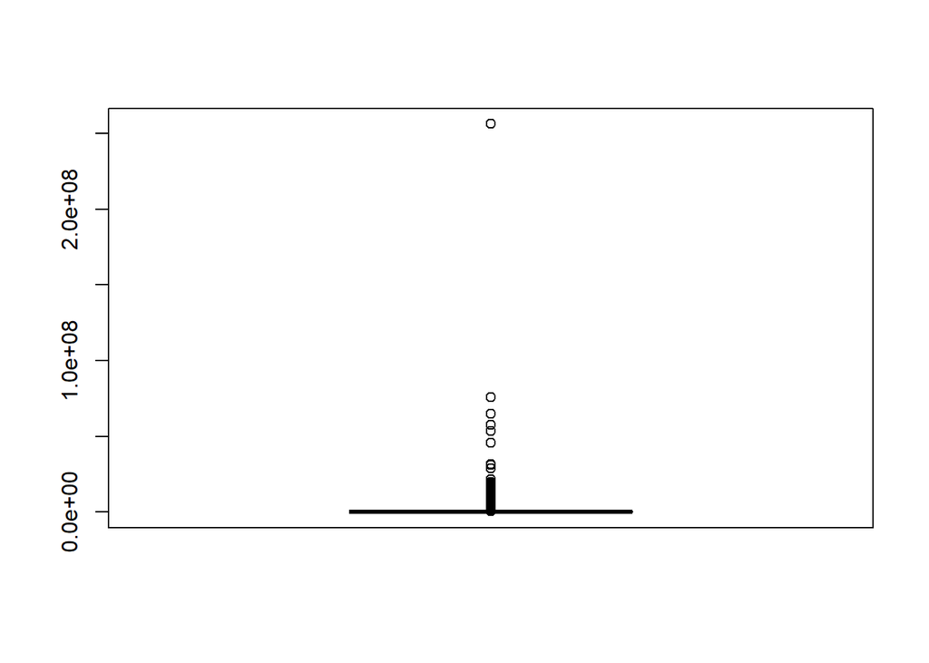

```r
# Subset combined dataset to FASTR-only
df_phyto_FASTR <- df_phyto %>% filter(Study == "FASTR")

# Identify if outliers are present
boxplot(df_phyto_FASTR$BV.um3.per.mL)
```

```r
# Identify 0.1% and 99.9% percentiles of the data
quartiles <- quantile(df_phyto_FASTR$BV.um3.per.mL,
                      probs=c(0.001, 0.999),
                      na.rm = TRUE)

# List upper cutoff (99.9%)
cutoff <- quartiles[2]

# Filter FASTR dataset to show all taxa above this 99.9% cutoff
df_outliers <- df_phyto_FASTR %>%
  filter(BV.um3.per.mL > cutoff)

df_outliers %>%
  select(DateTime,Taxon,BV.um3.per.mL) %>%
  kable(caption = "Al")## 4 of top 6 are Spirogyra.
```

Al

| DateTime | Taxon | BV.um3.per.mL |
| --- | --- | --- |
| 2015-08-27 10:04:00 | Spirogyra sp. | 53284341 |
| 2015-09-01 11:55:00 | Spirogyra sp. | 57390494 |
| 2016-03-24 08:26:00 | cf. Cyclotella sp. | 45565715 |
| 2016-07-07 09:40:00 | Cyclotella sp. | 31747497 |
| 2016-09-13 12:17:00 | Spirogyra sp. | 256335927 |
| 2017-09-13 12:10:00 | Spirogyra sp. | 76015935 |
| 2018-08-02 10:15:00 | Ulnaria ulna | 65089153 |

```r
df_phyto_FASTR %>% filter(Genus == "Spirogyra")# Only 5 total samples w/ Spirogyra
```

```
## # A tibble: 5 × 18
##   DateTime            Month  Year StationCode Region     Study Group Taxon Genus
##   <dttm>              <ord> <dbl> <chr>       <chr>      <chr> <chr> <chr> <chr>
## 1 2015-08-27 10:04:00 Aug    2015 LIB         Downstream FASTR Gree… Spir… Spir…
## 2 2015-09-01 11:55:00 Sep    2015 BL5         Downstream FASTR Gree… Spir… Spir…
## 3 2016-08-02 12:53:00 Aug    2016 RVB         Downstream FASTR Gree… Spir… Spir…
## 4 2016-09-13 12:17:00 Sep    2016 RYI         Downstream FASTR Gree… Spir… Spir…
## 5 2017-09-13 12:10:00 Sep    2017 BL5         Downstream FASTR Gree… Spir… Spir…
## # ℹ 9 more variables: Species <chr>, GALD <dbl>, BV.Avg <dbl>,
## #   Units.per.mL <dbl>, BV.um3.per.mL <dbl>, Cells.per.mL <dbl>,
## #   Biomass.ug.C <dbl>, BM.ug.per.mL <dbl>, LCEFA.per.mL <dbl>
```

```r
# Decision: Remove Spirogyra from datasets
# 4/5 are above 99.9% cutoff, 5th is also highly abundant
# These are benthic algae that clump, more likely to be "bullseye" samples
# that got a big blob or clump

# Remove Spirogyra from FASTR and combined dataset
df_phyto_FASTR <- df_phyto_FASTR %>%
  filter(Genus != "Spirogyra")

df_phyto <- df_phyto %>%
  filter(Genus != "Spirogyra")
```

## Add FASTR-Specific Metadata

This section adds metadata specific to the FASTR project to a subset of the data. EMP data is not included in this data frame as the categories do not apply to it.

Code for Merging Flow Designations was provided by Cat Pien and includes 45 days limit on either end of the flow pulse. Code was tweaked by TF in May 2022 to include greater-than or equal-to signs avoid inadvertently removing samples falling on the exact dates of pre- and post-flow phases.

```r
# Set levels so that Upstream stations appear before Downstream in graphs
df_phyto_FASTR$Region <- factor(df_phyto_FASTR$Region,
                           levels = c("Upstream","Downstream"))

# Import flow pulse dates and categories
df_flow_designation <- read_csv(here("phyto-final",
                                     "CSVs",
                                     "FlowDatesDesignations_45days.csv"),
                                show_col_types = FALSE)

# Remove column with net flow days. Won't be used in any analyses.
df_flow_designation <- df_flow_designation %>% select(!(NetFlowDays))

# Format dates as dates in each of the 4 date columns
df_flow_designation <- df_flow_designation %>%
  mutate(across(PreFlowStart:PostFlowEnd, mdy))

# Merge data from FlowDesignation Table (Water Year Type, Flow days and type)
df_phyto_FASTR <- inner_join(df_phyto_FASTR,
                             df_flow_designation,
                             by = "Year")

# Label samples with the appropriate phase (Pre-During-Post) and filter
# FASTR phyto data to include only samples collected within the flow pulse window
df_phyto_FASTR <- df_phyto_FASTR %>%
  mutate(ActionPhase = ifelse(DateTime > PreFlowStart & DateTime < PreFlowEnd, "Before", NA)) %>%
  mutate(ActionPhase = replace(ActionPhase, DateTime >= PreFlowEnd & DateTime < PostFlowStart, "During")) %>%
  mutate(ActionPhase = replace(ActionPhase, DateTime >= PostFlowStart & DateTime < PostFlowEnd, "After")) %>%
  filter(!is.na(ActionPhase)) %>%
  select(-c(PreFlowStart:PostFlowEnd))

# Order the new ActionPhase so that it plots in the order Pre < During < Post
phase.order <- c("Before","During","After")
df_phyto_FASTR$ActionPhase <- factor(as.character(df_phyto_FASTR$ActionPhase),
                                     levels = phase.order)

# Add in Flow Pulse Category Data
df_pulse_category <- read_csv(here("phyto-final","CSVs","FlowPulseType.csv"),
                              show_col_types = FALSE)

df_pulse_category <- df_pulse_category %>%
  rename("FlowPulseCategory" = "FlowPulseType")

# Add Flow Pulse Category to phytoplankton data frame
df_phyto_FASTR <- left_join(df_phyto_FASTR, df_pulse_category, by = "Year")

# Create a list of stations used for FASTR
stations <- c("RMB","RCS","RD22","I80","LIS","STTD","BL5","LIB","RYI","RVB")

# Re-order stations from North to South
df_phyto_FASTR$StationCode <- factor(as.character(df_phyto_FASTR$StationCode),
                                     levels = stations)
## Relocate metadata columns
df_phyto_FASTR <- df_phyto_FASTR %>%
  relocate(FlowPulseCategory, .before = ActionPhase) %>%
  relocate(WYType:ActionPhase, .before = GALD) %>%
  relocate(Biomass.ug.C, .after = BV.Avg)
```

## Create New Data Frames summarizing by Genus and Algal Group

```r
# Summarize by algal group
df_phyto_FASTR_grp <- df_phyto_FASTR %>%
  group_by(Year, Month, Region, ActionPhase, DateTime, StationCode, Group) %>%
  summarize(across(Units.per.mL:LCEFA.per.mL, ~sum(.x, na.rm = TRUE))) %>%
  ungroup
```

```
## 'DateTime', 'StationCode'. You can override using the `.groups` argument.
```

```r
# Summarize by genus
df_phyto_FASTR_gen <- df_phyto_FASTR %>%
  group_by(Year, Month, Region, ActionPhase, DateTime, StationCode, Genus) %>%
  summarize(across(Units.per.mL:LCEFA.per.mL, ~sum(.x, na.rm = TRUE))) %>%
  ungroup
```

```
## 'DateTime', 'StationCode'. You can override using the `.groups` argument.
```

```r
# Set group display order
group.order <- c("Diatoms",
                 "Cyanobacteria",
                 "Green Algae",
                 "Cryptophytes",
                 "Ciliates",
                 "Dinoflagellates",
                 "Golden Algae",
                 "Other")

df_phyto_FASTR_grp$Group <- factor(as.character(df_phyto_FASTR_grp$Group),
                                   levels =  group.order)

# Summarize totals
df_phyto_FASTR_sum <- df_phyto_FASTR %>%
  group_by(Year, Month, DateTime, StationCode, Region, WYType, FlowPulseType, FlowPulseCategory, ActionPhase) %>%
  summarize(across(Units.per.mL:LCEFA.per.mL, ~sum(.x, na.rm = TRUE))) %>%
  rename("Total.Units.per.mL" = "Units.per.mL") %>%
  rename("Total.BV.per.mL" = "BV.um3.per.mL") %>%
  rename("Total.Cells.per.mL" = "Cells.per.mL") %>%
  rename("Total.BM.per.mL" = "BM.ug.per.mL") %>%
  rename("Total.LCEFA.per.mL" = "LCEFA.per.mL") %>%
  ungroup
```

```
## 'Region', 'WYType', 'FlowPulseType', 'FlowPulseCategory'. You can override
```

```r
# Separate out data frames by density type and add zeros
# Biovolume Density + Group
df_phyto_FASTR_grp_BV <- df_phyto_FASTR_grp %>%
  select(Year:Group,BV.um3.per.mL)

# Add zeros for taxa that weren't detected
temp <- pivot_wider(df_phyto_FASTR_grp_BV,
                    names_from = Group,
                    values_from = BV.um3.per.mL,
                    values_fill = 0)

df_phyto_FASTR_grp_BV <- pivot_longer(temp,
                             cols = Cyanobacteria:last_col(),
                             names_to = "Group",
                             values_to = "BV.um3.per.mL")

# Create Biovolume-only data frame at genus level
df_phyto_FASTR_gen_BV <- df_phyto_FASTR_gen %>%
  select(Year:Genus,BV.um3.per.mL)

temp <- pivot_wider(df_phyto_FASTR_gen_BV,
                    names_from = Genus,
                    values_from = BV.um3.per.mL,
                    values_fill = 0)

df_phyto_FASTR_gen_BV <- pivot_longer(temp,
                                      cols = Chlorella:last_col(),
                                      names_to = "Genus",
                                      values_to = "BV.um3.per.mL")

rm(temp)
```

## Multivariate Calculations

Use the vegan package in R to calculate the Bray-Curtis similarity coefficients for phytoplankton community comparisons in each year (2014 - 2019). A good rule of thumb: stress < 0.05 provides an excellent representation in reduced dimensions, < 0.1 is great, < 0.2 is good/ok, and stress < 0.3 provides a poor representation.

```
## Square root transformation
## Wisconsin double standardization
## *** Best solution repeated 1 times
```

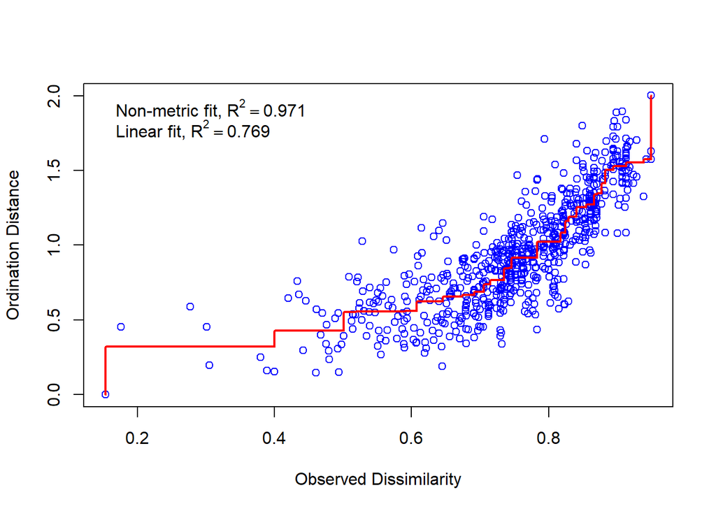

```
## Square root transformation
## Wisconsin double standardization
## *** Best solution repeated 2 times
```

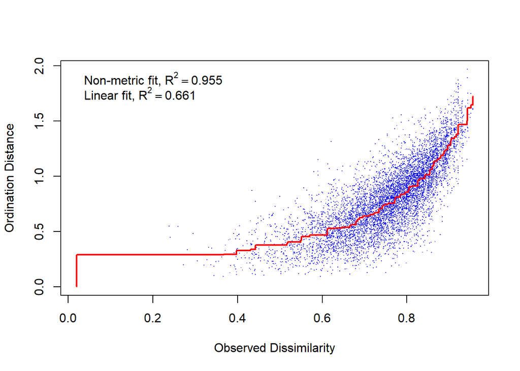

```
## Square root transformation
## Wisconsin double standardization
## *** Best solution repeated 13 times
```

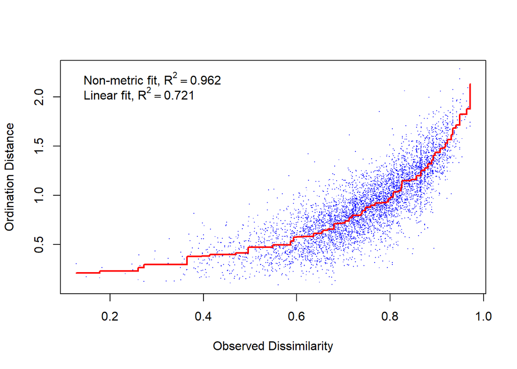

```
## Square root transformation
## Wisconsin double standardization
## *** Best solution repeated 1 times
```

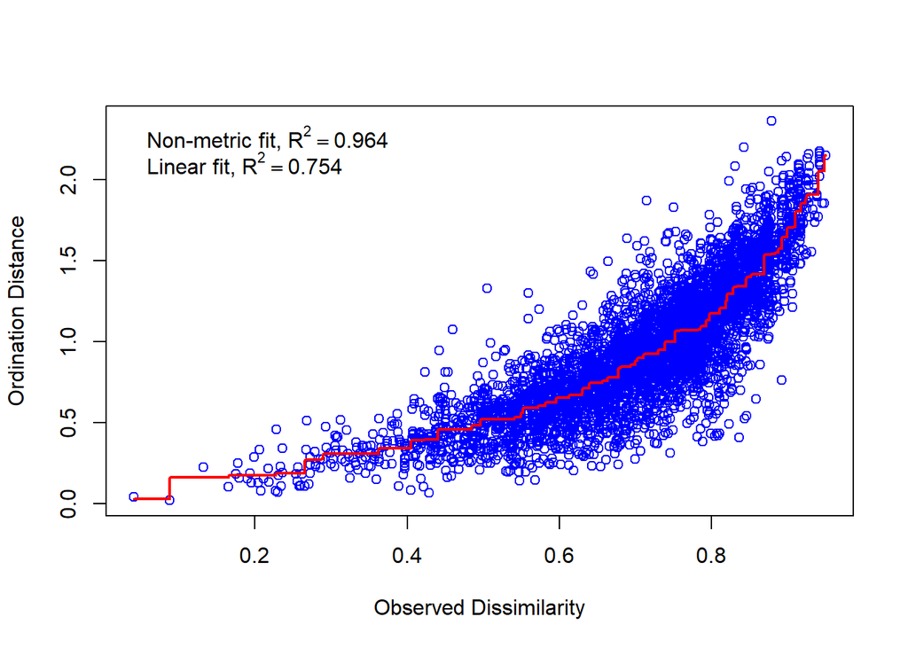

```
## Square root transformation
## Wisconsin double standardization
## *** Best solution was not repeated -- monoMDS stopping criteria:
##    331: no. of iterations >= maxit
##    169: stress ratio > sratmax
```

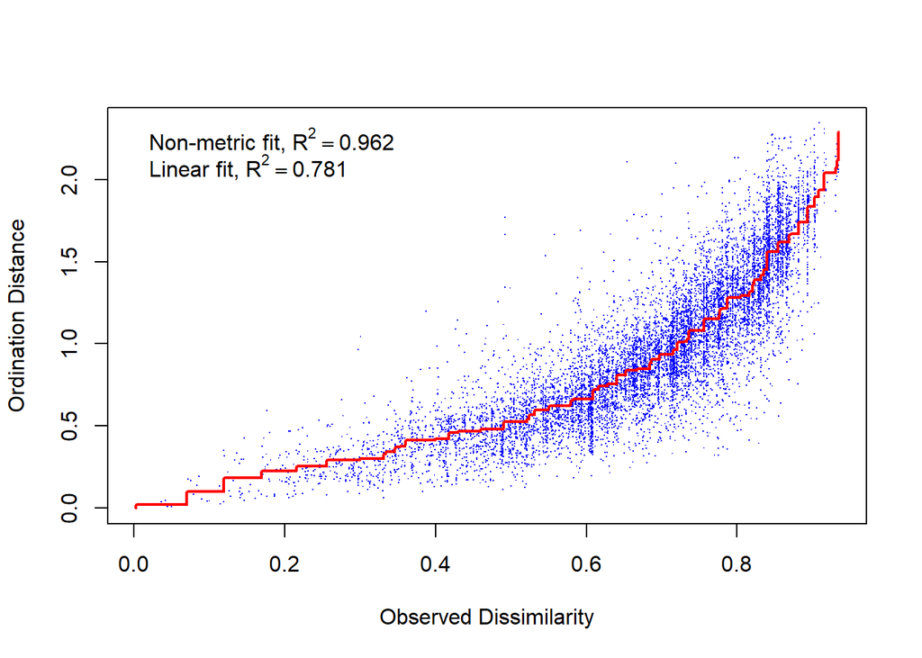

```
## Square root transformation
## Wisconsin double standardization
## *** Best solution repeated 2 times
```

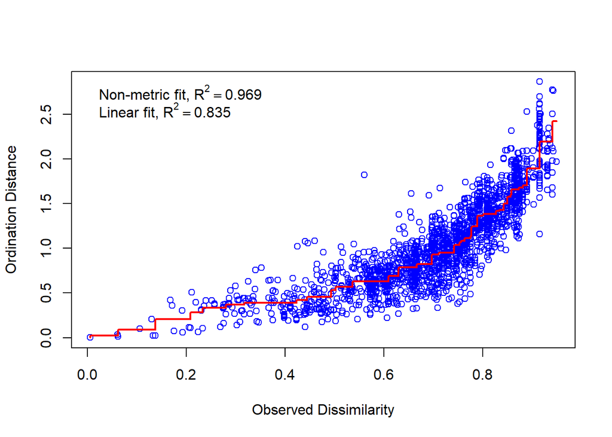

## Save RData files for use in analysis